# hw03-exercises

Loading the r packages:

```r
library(tidyverse)
library(gapminder)
library(ggridges)
library(scales)
library(DT)
library(tsibble)
```

# Option 1: Abundance of countries with low life expectancy over time by continent

Well, what is considered a low life expectancy? Lets take the median age for all life expectancies in the gapminder data frame and use it as our criteria to determine if life expectancy is high or low:

```r
median(gapminder$lifeExp)
```

```
## [1] 60.7125
```

So 60.7 is considered neither high or low life expectancy, but below this number is considered low and above is high.

Lets take our gapminder data frame and add a column called lowLifeExp (low life expectancy) to see if the life expectancy is less than 60.7. Next we will filter gapminder so that we only have rows with low life expectancies where lowLifeExp equals TRUE. After grouping gapminder by continent and year, we can count the number of observations for each group to find the number of countries on each continent have a life expectancy less than 60.7 for each year, with its mean life expectancy, using the summarize function. Here is the data:

```r
DT::datatable(gapminder_option1 <- gapminder %>%
  mutate(lowLifeExp = lifeExp < 60.7) %>%
  filter(lowLifeExp == TRUE) %>%
  group_by(continent, year) %>%
  summarize(meanLifeExp = mean(lifeExp), n = n()))
```

|  | continent | year | meanLifeExp | n |
| --- | --- | --- | --- | --- |
| 1 | Africa | 1952 | 39.1355 | 52 |
| 2 | Africa | 1957 | 41.2663461538462 | 52 |
| 3 | Africa | 1962 | 43.3194423076923 | 52 |
| 4 | Africa | 1967 | 45.0164509803922 | 51 |
| 5 | Africa | 1972 | 46.80462 | 50 |
| 6 | Africa | 1977 | 48.92376 | 50 |
| 7 | Africa | 1982 | 49.938652173913 | 46 |
| 8 | Africa | 1987 | 50.3000487804878 | 41 |
| 9 | Africa | 1992 | 49.976775 | 40 |
| 10 | Africa | 1997 | 50.6986136363636 | 44 |

[output cut: 31 more lines]

Lets plot our findings for a more visually pleasing way. We’ll make a new plot for each continent using facet_wrap, where the points represent the average life expectancy for a plot of number of countries with low life expectancy vs. year:

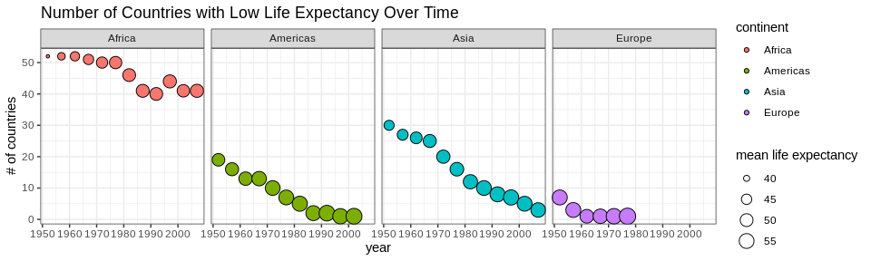

```r
ggplot(gapminder_option1, aes(year, n, size = meanLifeExp,  fill = continent)) +
  facet_wrap(~ continent, nrow = 1) +
  geom_point(shape = 21) +
  ylab('# of countries') +
  ggtitle('Number of Countries with Low Life Expectancy Over Time') +
  labs(size = "mean life expectancy") +
  theme_bw()
```

RESULTS: Africa has the highest number of countries with a low life expectancy. Europe has a low life expectancy only from 1952 till 1977. Oceania has a high life expectancy from 1952 to 2007.

Note: Oceania has no life Expectancies below the threshold 60.7 and, therefore, has no low life expectancy from 1952 to 2007 with no plot depicted above

```r
gapminder %>%
  filter(continent == 'Oceania' & lifeExp < 60.7)
```

```
## # A tibble: 0 x 6
## # … with 6 variables: country <fct>, continent <fct>, year <int>,
## #   lifeExp <dbl>, pop <int>, gdpPercap <dbl>
```

# Option 2: Minimum and maximum GDP per capita

In order to find the minimum and maximum GDP per capita for all continents, we will group gapminder by continent. Next, 4 new columns will be made for the minimum GDP per capita (min_gdp) and its corresponding country (country_min_gdp), and the maximum GDP per capita (max_gdp) and its corresponding country (country_max_gdp):

```r
knitr::kable(gapminder_option2 <- gapminder %>%
  group_by(continent) %>%
  summarize(min_gdp = min(gdpPercap), country_min_gdp = country[gdpPercap == min_gdp],
            max_gdp = max(gdpPercap), country_max_gdp = country[gdpPercap == max_gdp]))
```

| continent | min_gdp | country_min_gdp | max_gdp | country_max_gdp |
| --- | --- | --- | --- | --- |
| Africa | 241.1659 | Congo, Dem. Rep. | 21951.21 | Libya |
| Americas | 1201.6372 | Haiti | 42951.65 | United States |
| Asia | 331.0000 | Myanmar | 113523.13 | Kuwait |
| Europe | 973.5332 | Bosnia and Herzegovina | 49357.19 | Norway |
| Oceania | 10039.5956 | Australia | 34435.37 | Australia |

Here is a plot of our results. Displayed is a bar graph of log10 of GDP per capita for its minimum and maximum for each continent. Red is for the maximum GDP per capita and blue is for the minimum GDP per capita. Alpha is set to 0.3 to see the layered bar graphs:

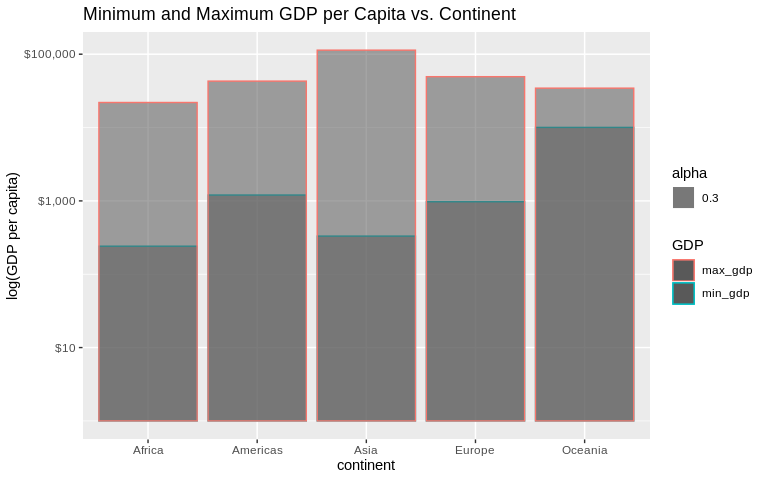

```r
ggplot(gapminder_option2, aes(continent, y , color = GDP)) +
  geom_col(aes( y = min_gdp, col = "min_gdp", alpha = 0.3)) +
  geom_col(aes( y = max_gdp, col = "max_gdp", alpha = 0.3)) +
  ylab("log(GDP per capita)") +
  scale_y_log10(labels = scales::dollar_format()) +
  ggtitle("Minimum and Maximum GDP per Capita vs. Continent ")
```

RESULTS: Asia has the highest GDP per capita while Africa has the lowest GDP per capita of the 5 continents for the period between 1952 to 2007

# Option 5: Change in continental life expectancy over time

How is life expectancy changing over time on different continents? First, lets group our gapminder data by country and arrange by year. Now we can calculate the increase in life expectancy (incLifeExp) in a new column by finding the difference in life expectancy for each country over time using the mutate function and difference functions. Lastly, we can drop all the NAs from the table that were from the first year data was collected for each country produced from the previous step:

```r
DT::datatable(gapminder_option5 <- gapminder %>%
  group_by(country) %>%
  arrange(year) %>%
  mutate(incLifeExp = difference(lifeExp)) %>%
  tidyr::drop_na())
```

|  | country | continent | year | lifeExp | pop | gdpPercap | incLifeExp |
| --- | --- | --- | --- | --- | --- | --- | --- |
| 1 | Afghanistan | Asia | 1957 | 30.332 | 9240934 | 820.8530296 | 1.531 |
| 2 | Albania | Europe | 1957 | 59.28 | 1476505 | 1942.284244 | 4.05 |
| 3 | Algeria | Africa | 1957 | 45.685 | 10270856 | 3013.976023 | 2.608 |
| 4 | Angola | Africa | 1957 | 31.999 | 4561361 | 3827.940465 | 1.984 |
| 5 | Argentina | Americas | 1957 | 64.399 | 19610538 | 6856.856212 | 1.914 |
| 6 | Australia | Oceania | 1957 | 70.33 | 9712569 | 10949.64959 | 1.20999999999999 |
| 7 | Austria | Europe | 1957 | 67.48 | 6965860 | 8842.59803 | 0.680000000000007 |
| 8 | Bahrain | Asia | 1957 | 53.832 | 138655 | 11635.79945 | 2.893 |
| 9 | Bangladesh | Asia | 1957 | 39.348 | 51365468 | 661.6374577 | 1.864 |
| 10 | Belgium | Europe | 1957 | 69.24 | 8989111 | 9714.960623 | 1.23999999999999 |

[output cut: 1552 more lines]

Lets plot our data for increase in life expectancy vs. year, creating a new plot for each continent using facet_wrap. The function geom_jitter was used to scatter the points slightly from left to right shown in yellow. A linear regression line was plotted from the data points in magenta.

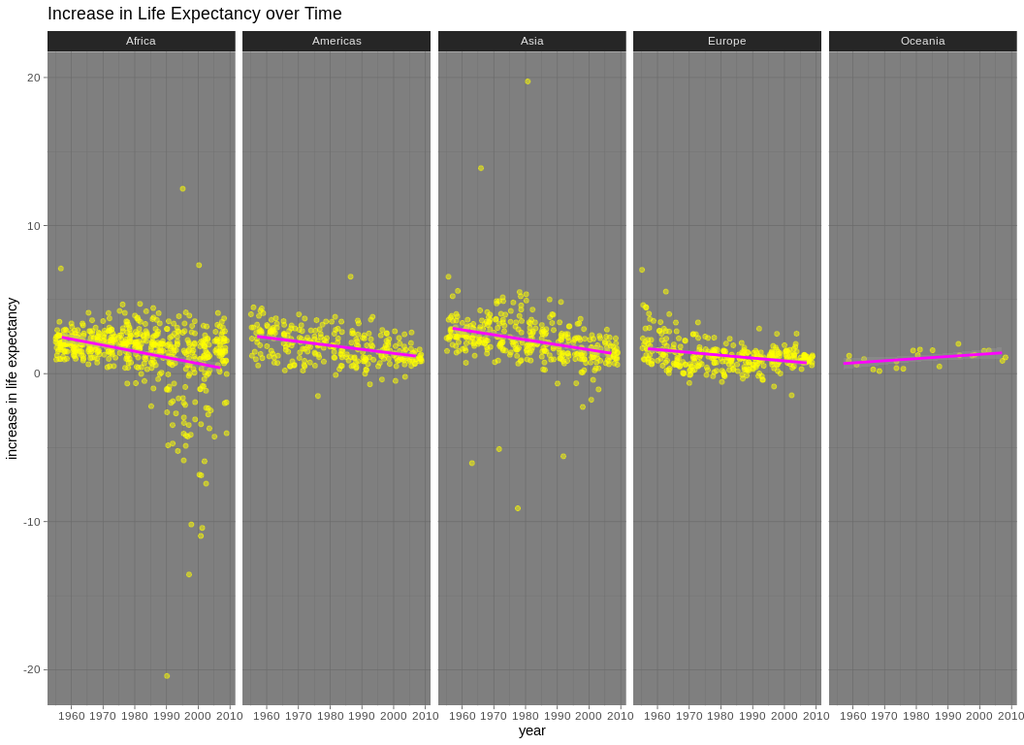

```r
ggplot(gapminder_option5, aes(year, incLifeExp)) +
  facet_wrap(~ continent, nrow = 1) +
  geom_jitter(alpha = 0.5, colour = 'yellow') +
  geom_smooth(method = "lm", colour = 'magenta') +
  ylab('increase in life expectancy') +
  ggtitle('Increase in Life Expectancy over Time') +
  theme_dark()
```

RESULTS: For all 5 continents most countries have an increase in life expectancy. The slope of the increase in life expectancy goes down over time for Africa, Asia, Americas, and Europe, but goes up for Oceania. Africa has the most countries with decreases in life expectancy.